# team

### 4. How do different bean origins compare in terms of the flavor of chocolates? Are beans from some places better than the other? Create both numerical and graphical summaries, and explain.

```r
# get country that on average produce the best rated bean
choco %>% group_by(CountryBeanOrigin) %>% summarise(avgRating = mean(Rating)) %>% arrange(-avgRating) %>% head(1)
```

```
## # A tibble: 1 x 2
##   CountryBeanOrigin avgRating
##   <chr>                 <dbl>
## 1 Tobago                 3.62
```

```r
# get country that on average produce the worst rated bean
choco %>% group_by(CountryBeanOrigin) %>% summarise(avgRating = mean(Rating)) %>% arrange(avgRating) %>% head(1)
```

```
## # A tibble: 1 x 2
##   CountryBeanOrigin avgRating
##   <chr>                 <dbl>
## 1 Puerto Rico            2.71
```

```r
choco %>% group_by(CountryBeanOrigin) %>% summarise(bestRating = max(Rating), worstRating = min(Rating), avgRating = mean(Rating)) %>% arrange(-avgRating)
```

```
## # A tibble: 62 x 4
##    CountryBeanOrigin   bestRating worstRating avgRating
##    <chr>                    <dbl>       <dbl>     <dbl>
##  1 Tobago                    4           3.25      3.62
##  2 Sao Tome & Principe       3.5         3.5       3.5
##  3 Solomon Islands           4           3         3.45
##  4 Congo                     3.75        2.75      3.32
##  5 Thailand                  3.75        2.75      3.3
##  6 Cuba                      3.75        2.5       3.29
##  7 Papua New Guinea          4           2.5       3.28
##  8 Haiti                     4           2.5       3.27
##  9 Madagascar                4           2.25      3.26
## 10 Vietnam                   4           2.75      3.26
## # ... with 52 more rows
```

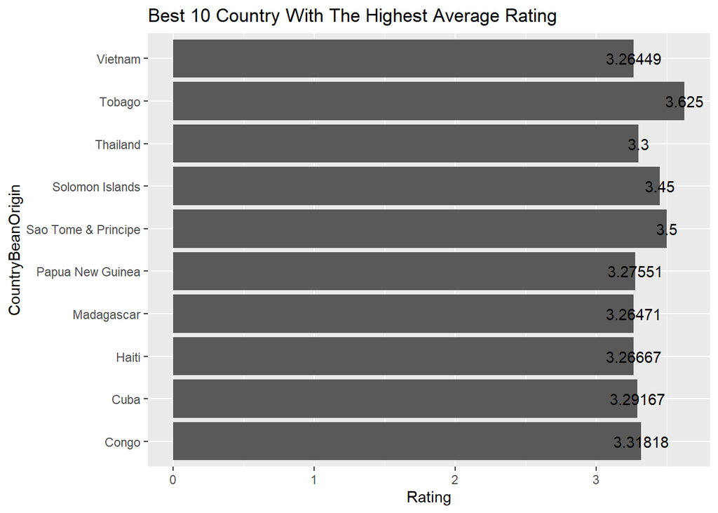

```r
# plot Best 10 Country With The Highest Average Rating
sortedData = choco %>% group_by(CountryBeanOrigin) %>% summarise(Rating = mean(Rating)) %>% arrange(-Rating) %>% head(10)
sortedData %>% ggplot(aes(CountryBeanOrigin, Rating)) + geom_col() + labs(title = "Best 10 Country With The Highest Average Rating") + coord_flip() + geom_text(aes(label = signif(Rating)))
```

```r
#choco %>% mutate(numFlavors = rowSums(!is.na(select(., Characteristics1:Characteristics4))))
choco$numFlavor <- rowSums(!is.na(choco[8:11]))
choco %>% group_by(CountryBeanOrigin) %>% filter(numFlavor %in% 4) %>% head()
```

```
## # A tibble: 6 x 14
## # Groups:   CountryBeanOrigin [4]
##     REF Company  Location ReviewDate CountryBeanOrigin SpecificBeanOrigin
##   <dbl> <chr>    <chr>         <dbl> <chr>             <chr>
## 1  2546 5150     U.S.A.         2021 Venezuela         Sur del Lago, batch 1
## 2  1011 A. Morin France         2013 Ecuador           Equateur
## 3  1015 A. Morin France         2013 Venezuela         Chuao
## 4  2206 A. Morin France         2018 Peru              Absolu
## 5  1470 Acalli   U.S.A.         2015 Peru              Tumbes, Norandino
## 6  2438 Aelan    Vanuatu        2019 Vanuatu           Malo Island, batch Ma20/~
## # ... with 8 more variables: Ingredients <chr>, Characteristics1 <chr>,
## #   Characteristics2 <chr>, Characteristics3 <chr>, Characteristics4 <chr>,
## #   Rating <dbl>, CocoaPercent <dbl>, numFlavor <dbl>
```

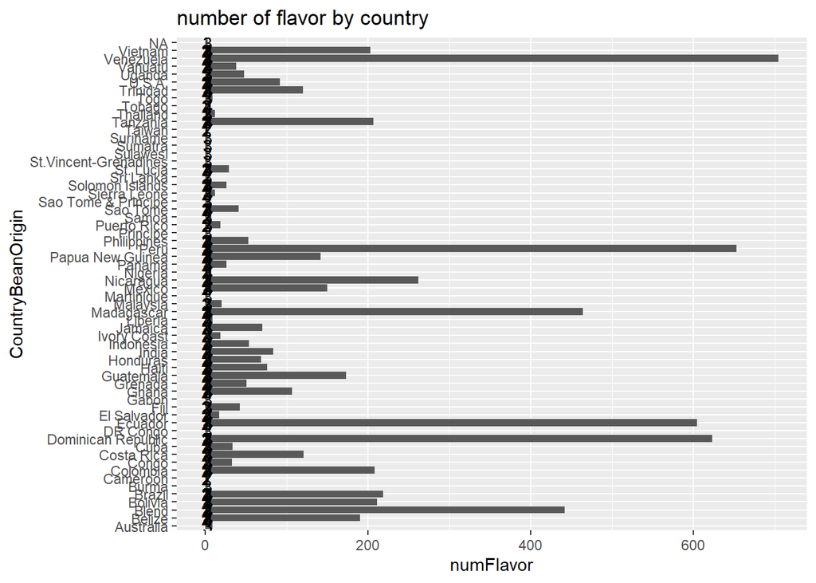

```r
choco %>% ggplot(aes(CountryBeanOrigin, numFlavor)) + geom_col() + labs(title = "number of flavor by country") + coord_flip() + geom_text(aes(label = signif(numFlavor)))
```

```r
choco %>% group_by(numFlavor) %>% summarise(avgRating = mean(Rating)) %>% head()
```

```
## # A tibble: 4 x 2
##   numFlavor avgRating
##       <dbl>     <dbl>
## 1         1      3.28
## 2         2      3.23
## 3         3      3.18
## 4         4      3.19
```

### 5. If you work on this lab by yourself, brainstorm two analyses you would like to perform. If you work with a teammate, brainstorm at least three analyses with your teammate. Describe in plain language what comparisons are you making. Create suitable numerical and graphical summaries for your analyses. Describe the results.

1. Comparison of Company to Chocolate Rating, Does Company effect Rating?

```r
groupings = summarise(group_by(choco, Company), avgRating=mean(Rating))
groupings
```

```
## # A tibble: 570 x 2
##    Company                       avgRating
##    <chr>                             <dbl>
##  1 5150                               3.32
##  2 A. Morin                           3.4
##  3 Acalli                             3.56
##  4 Adi aka Fijiana (Easy In Ltd)      3.25
##  5 Aelan                              2.75
##  6 Aequare (Gianduja)                 2.88
##  7 Ah Cacao                           3
##  8 Akesson's (Pralus)                 3.08
##  9 Alain Ducasse                      2.83
## 10 Alexandre                          3.5
## # ... with 560 more rows
```

[figure not shown]

```r
ggplot(groupings, aes(x=Company, y=avgRating)) +
    geom_bar(stat='identity')
```

2. Comparison of ReviewDate to Chocolate Rating, Does ReviewDate effect Rating?

```r
groupings = summarise(group_by(choco, ReviewDate), avgRating=mean(Rating))
groupings
```

```
## # A tibble: 16 x 2
##    ReviewDate avgRating
##         <dbl>     <dbl>
##  1       2006      3.00
##  2       2007      3.10
##  3       2008      3
##  4       2009      3.07
##  5       2010      3.15
##  6       2011      3.26
##  7       2012      3.18
##  8       2013      3.20
##  9       2014      3.19
## 10       2015      3.24
## 11       2016      3.23
## 12       2017      3.36
## 13       2018      3.19
## 14       2019      3.13
## 15       2020      3.26
## 16       2021      3.32
```

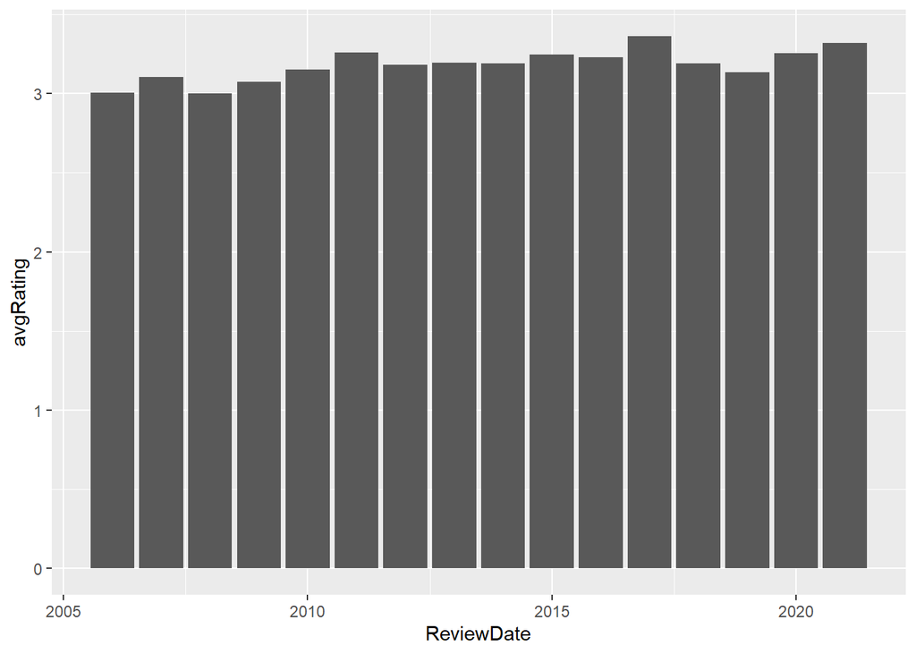

```r
ggplot(groupings, aes(x=ReviewDate, y=avgRating)) +
    geom_bar(stat='identity')
```

```r
groupings = summarise(group_by(choco, SpecificBeanOrigin), avgRating=mean(Rating))
groupings
```

```
## # A tibble: 1,544 x 2
##    SpecificBeanOrigin                                      avgRating
##    <chr>                                                       <dbl>
##  1 "\"Classic Dark\", Ecuador-Guatemala-Dom. Rep."              3.5
##  2 "\"Cocoa Nibs\", Hispaniola w/ nibs"                         3.75
##  3 "\"heirloom\", Arriba Nacional"                              3.5
##  4 "\"Peace of Wild Things\""                                   3
##  5 "\"Roasted Cocoa Nibs\", Latin America Blend, b.060321"      3
##  6 "100 percent"                                                1.5
##  7 "2009 Hapa Nibby, Dominican Rep., Bali"                      3.75
##  8 "A case of the Xerces Blues, triple roast"                   3.5
##  9 "Abinao, West Africa"                                        2.5
## 10 "ABOCFA Coop"                                                4
## # ... with 1,534 more rows
```

[figure not shown]

```r
ggplot(groupings, aes(x=SpecificBeanOrigin, y=avgRating)) +
    geom_bar(stat='identity')
```